# В погоне за счастьем

Анализ паттернов трудовой мобильности на данных единой системы учета трудовых договоров Республики Казахстан

Авторы: *Алдияров Мадияр, Алибеков Дастан, Казтаева Адина, Қорғанбек Медина, Оспанов Әділхан*

Куратор: *Медеуов Дархан*

Под редакцией: *Серебренникова Дмитрия*

<sub>Kazakhstan Sociology Lab совместно с Центром развития трудовых ресурсов Республики Казахстан представляют результат работы проектной группы студентов по направлению «Исследования занятости». В работе рассматриваются агрегированные данные Единой системы учета трудовых договоров (ЕСУТД) Республики Казахстан. Используя данные о зарегистрированных трудовых договорах анализируются тенденции трудовой мобильности в Казахстане с 2020 по 2023 год. Полученные результаты свидетельствуют, что трудовая мобильность имеет централизованную и иерархическую структуру: большинство новых контрактов заключается в крупных городских агломерациях (например, в Астане, Алматы и Шымкенте). Региональные центры в свою очередь выполняют роль “промежуточных остановк” в трудовой карьере казахстанцев. В то же время, выявлены региональные кластеры трудовой миграции в стране, не совпадающие с привычным административным делением</sub>

<sub>**Ключевые слова**: *миграция, трудовая мобильность, сетевой анализ, региональная статистика, моделирование миграционных потоков*</sub>

<sub>Kazakhstan Sociology Lab in collaboration with the Workforce Development Center of the Republic of Kazakhstan present the result of a project group focusing on «Labour studies». This paper examines aggregated data from the Single Accounting System for Employment Agreements (SASEA) of the Republic of Kazakhstan. Using data on the conclusion of new employment contracts across different regions, we analyze labor migration trends in Kazakhstan from 2020 to 2023. The findings suggest that labor migration exhibits a centralized and hierarchical structure, with large urban agglomerations (e.g., Astana, Almaty, and Shymkent) driving the majority of workplace transitions. Additionally, the “intermediary” role of smaller cities is revealed, with these cities often serving as intermediate “stops” in the labor careers of Kazakhstanis.</sub>

<sub>**Keywords**: *migration, labor mobility, network analysis, regional statistics, migration workflows modelling*</sub>

<sub>*Мы выражаем искреннюю благодарность вице-президенту Центра развития трудовых ресурсов Республики Казахстан, Байкулакову Шалкару Баяхметовичу, за предоставленные данные и содействие в научно-исследовательской работе.*</sub>

<sub><sup>Алдияров М., Алибеков М., Казтаева А., Қорғанбек М., Оспанов Ә. В погоне за счастьем? Анализ паттернов трудовой мобильности на данных единой системы учета трудовых договоров Республики Казахстан. Аналитический отчет / под ред. Волковой Н., Серебренникова Д.; Kazakhstan Sociology Lab. — Астана.: 2024.</sup></sub>

## Executive Summary | Основные результаты

Трудовая мобильность, понимаемая как смена места работы, — это многранное явление, которое отражает не только индивидуальные решения, но и более широкие структурные и системные тенденции в социально-экономической сфере. По данным Международной организации по миграции в Казахстане ([2021](https://web.archive.org/web/20210303212626/https://publications.iom.int/books/kazahkstan-advanced-migration-profile-2014-2019-russian)), в 2019 году в миграционные процессы внутри страны было вовлечено 1 млн. 115 тысяч человек. Население страны активно меняет своё место жительства и нет оснований считать, что масштабы этого процесса станут менее выраженными в ближайшем будущем.

В этом контексте важно понять почему одни регионы становятся центрами притяжения, а другие теряют свои трудовые и интеллектуальные ресурсы? Какие силы движут людьми в поисках лучшей жизни — экономическое неравенство, социальные сети или особенности жизненного пути?

В представляемой работе мы предлагаем свою попытку ответить на эти вопросы на агрегированных данных официально зарегистрированных в Казахстане трудовых контрактов в 2020-2024 гг. из информационной системы «Единая система учета трудовых договоров». При анализе мы применяем статистические методы, анализируем миграционные сети и моделируем их динамику, исследуем паттерны трудовой мобильности.

Мы фиксируем географическое распределение и половозрастные особенности для разных видов экономической деятельности: в городах индивиды чаще заключают трудовые договора в сфере розничной торговли, а в сельской местности - в сфере образования. Мы также анализируем структуру географической трудовой мобильности и делаем вывод о ее централизованности и иерархичности, где чаще всего находят новую работу в крупных городских аггломерациях (г. Астана, г. Алматы, г. Шымкент). Мы также обнаруживаем “посредническую” роль городов меньшего масштаба, которые часто выступают в роли промежуточных “остановок” в трудовой карьере Казахстанцев.

## 1. Введение: Трудовая мобильность как социальный процесс

В современных социальных науках трудовая мобильность рассматривается как сложный, социально-экономический процесс. Решая сменить работу индивиды принимают во внимание значительное количество факторов, начиная от заработной платы и инфраструктуры на новом месте, заканчивая политическими и культурными особенностями трудового коллектива. Важность неэкономических факторов вырастает еще сильнее, когда трудовая мобильность связана с переездом в новый регион.

Социологические и экономические исследования трудовой мобильности часто видят ее как необходимое условия для стабильного экономического роста. По этой причине, понимание того какие факторы имеют значение для мобильности и миграции является важным базисом для разработки государственных программ, нацеленных на развитие экономики и инфраструктуры. Какими способами можно привлечь квалифицированне кадры в определенные регионы? Какими стимулами можно удержать работников после переезда? Что именно в определенных центрах притяжения привлекает соискателей? Ответы на все эти вопросы требуют детального исследования конкретных фактов смены работы и переезда.

В целом, существующие исследования факторов мобильности имеют две общие черты. Во-первых, большинство исследований рассматривают мобильность с сугубо экономической точки зрения, предполагая, что большинство, если не все, миграции - это трудовая миграция, обусловленная экономическими стимулами. Вторая доминирующая идея - это рассматривать мобильность как характеристику районов, изучая корреляции между чистыми показателями миграции между регионами и их социо-экономическими характеристиками, учитывая также географическое расстояние между ними.

Иными словами, в классическом понимании, индивиды, во-первых, меняет место проживания в поисках работы и соответственно, регионы с большим количеством высокооплачиваемых рабочих мест привлекают большее число мигрантов. А во-вторых, при прочих равных условиях, миграционный поток между географически далекими регионами будет меньше чем между близкими.

Эти два базовых фактора — расстояние и экономическое благосостояние — легли в основу, пожалуй, самой известной модели миграции: гравитационной. Согласно этой модели, число переезжающих между регионами прямо пропорционально “экономическим массам” (например, численности населения или уровню экономического развития) этих регионов и обратно пропорционально квадрату расстояния между ними.

Практические исследования довольно быстро показали, что, хотя гравитационная модель в целом хорошо описывает основные паттерны миграции, она имеет свои ограничения. В частности, модель не учитывает множество факторов, таких как культурные различия, социальные связи или политические барьеры, которые также могут существенно влиять на миграционные потоки.

В представляемой работе мы анализируем паттерны миграции и тестируем гравитационную модель на на агрегированных данных официально зарегистрированных в Казахстане трудовых контрактов в 2020-2024 гг. из информационной системы «Единая система учета трудовых договоров».

# 2. Исторический обзор миграции в Казахстане

Для понимания особенностей нынешней трудовой мобильности необходимо коротко описать изменение основных регуляторных механизмов в сфере труда и миграции. С момента обретения Независимости в 1991 году миграция регулировалась рядом законов, постановлений и других государственных программ, направленных на управление как внутренней, так и внешней миграцией. Одним из первых важнейших шагов стал Закон «Об иммиграции» 1992 года, который зафиксировал правовые механизмы для возвращения этнических казахов на историческую родину. Тогда Правительство выразило готовность поддерживать казахов, проживающих за границей и стремящихся вернуться. В 1997 году был принят Закон «О миграции населения», расширивший регулирование миграционных потоков, включая трудовую и вынужденную миграцию. 17 августа 2000 года была принята «Концепция государственной демографической и миграционной политики Республики Казахстан», задавшая основные принципы и методы управления миграцией.

В концепции особо отмечена важность миграции для безопасности, социального согласия и экономики страны. Особое внимание уделялось регулированию трудовой миграции. Согласно концепции, значительные изменения ожидались в размещении производственных мощностей, что должно было привести к развитию восточных, северных, западных и южных регионов, а в центральной части страны — к развитию городов с ориентиром на горнодобывающую промышленность.

Концепция также предполагала создание условий для переселения из зон с неэффективным производством в регионы с лучшими условиями для жизни и работы. Расширение рабочих мест должно было вызвать приток экономически активного населения в регионы с высокоразвитыми ресурсами и инфраструктурой. Ожидалось, что внутренние миграционные потоки будут ориентированы на зоны эффективного землепользования. Постепенно, наряду с традиционными перемещениями из сельских районов в города, могла появиться новая тенденция — переселение населения из южных регионов в северные.

В конце 2022 года правительство утвердило новую «Концепцию миграционной политики Республики Казахстан на 2023–2027 годы» (Постановление № 961 от 30 ноября 2022 года). Этот документ включал семь направлений для более эффективного регулирования миграции, включая трудовые потоки, с учетом демографических, экономических и социокультурных приоритетов.В последние годы основные внутренние потоки направлены из сельских районов в областные и районные центры, а также в крупные города: Алматы, Астану и Шымкент.

По данным Министерства труда и социальной защиты РК, за год с 1 июля 2023 до 1 июля 2024 года внутренняя миграция увеличилась в 1,7 раза (с 397 тыс. до 688 тыс. человек). В этот период Астана, Алматы и Шымкент оставались главными центрами притяжения, куда переехали 64 тыс., 60 тыс. и 31 тыс. человек соответственно. По оценкам АО «ЦРТР», численность населения мегаполисов к 2050 году может вырасти на 5,4 млн человек, составив 10,2 млн или 37% от общего населения Казахстана. Ожидается, что без дополнительных мер региональная диспропорция в распределении населения будет увеличиваться: население восьми регионов может сократиться на 869 тыс. человек, включая области Абай, Ұлытау, Акмолинскую, Карагандинскую, Костанайскую, Павлодарскую, Северо-Казахстанскую и Восточно-Казахстанскую.

# 3. Современные подходы к количественному изучению миграционных потоков

## 3.1. Социально-экономические факторы миграции

Экономические факторы всегда имели важное значение в принятии решений о миграции. Различия в заработной плате, возможностях трудоустройства и экономическом процветании между регионами или странами часто служат основными мотивами для переезда. Более высокий уровень ВВП в регионах назначения сильно коррелирует с увеличением притока мигрантов, в то время как безработица в регионах убытия способствует оттоку мигрантов, а безработица в регионах назначения препятствует ему (Aksoy & Yıldırım, 2023). Миграция из сельской местности в города была отличительной чертой экономического развития, создавая средний класс в таких странах, как Китай, и способствуя урбанизации в развивающихся странах (Dietz et al., 2023).

Географические и пространственные факторы также играют свою роль. Как уже говорилось расстояние между пунктами убытия и прибытия сдерживает миграцию, при этом в более близких регионах наблюдаются более высокие потоки. Помимо физического расстояния, однако, важнейшим фактором является политическая и культурная близость регионов. Например, исследуя Турецкие официальные данные, исследователи показали, что миграционные потоки между провинциями, разделяющими схожие политические предпочтения более интенсивны, причем политическое расстояние иногда играет более важную роль, чем географическое (Aksoy & Yıldırım, 2023).

Социальные сети также определяют динамику миграции. Межличностные связи значительно снижают затраты и риски, связанные с миграцией, способствуя развитию миграционных коридоров (Massey et al., 1994). Созданные сети совместного проживания в регионах назначения снижают ощутимые барьеры, такие как доступ к жилью или работе, и стимулируют дальнейшую миграцию. Этот «сетевой эффект» особенно заметен для мигрантов из более бедных стран, где доступ к ресурсам через социальные связи становится жизненно важным (Pedersen et al., 2008).

Демографические показатели и события жизненного цикла также влияют на характер миграции. Возраст имеет тесную связь с мобильностью: пик миграции приходится на молодое совершеннолетие, что обусловлено такими жизненными переходами, как начало карьеры или создание семьи, и снижается по мере старения (Rogers & Castro, 1981). События, связанные с семьей, такие как вступление в брак или рождение ребенка, влияют на вероятность миграции, причем молодые семьи чаще переезжают (Dietz et al., 2023). Эти тенденции подчеркивают глубокую взаимосвязь между миграцией и жизненным циклом человека.

Важным фактором миграции является урбанизация и пост-урбанизация. Первый процесс более характерен для развивающихся экономик, где, как мы уже отмечали, миграция из сельских районов в города тесно связана с индустриализацией, ростом числа рабочих мест, и формированием среднего класса (Dietz et al., 2023).

Постурбанизация же феномен более характерный для развитых экономик (например, США), где миграционный фокус сместился из крупных столичных центров в пригороды и малые города (Boustan & Shertzer, 2013). Рост стоимости жилья в городских центрах приводит к оттоку населения, в то время как небольшие города с относительно доступным жильем переживают значительный рост (Gebeloff et al., 2021). Эти закономерности подчеркивают растущее значение доступности жилья и качества жизни как факторов, определяющих миграцию.

## 3.2 Проблемы, связанные с измерением и моделированием миграции

Как и со многими прочими сложными социальными явлениями, изучение миграции имеет свою методологические вызовы. Условно, эти вызовы можно разделить на две категории: трудности с измерением и трудности с моделированием.

Первая категория относительно понятная, точное измерение миграции - это сложная задача. Различия в определениях, методах сбора данных и стандартах отчетности затрудняют межрегиональные и лонгитюдные сравнения (Willekens, 2016). В зависимости от того, что считать миграцией, конечные данные могут принципиально отличаться и соответственно часть выводом сделанных по этим данным будет больше отражать особенности сбора, нежели реальное положение дел. Отдельная проблема всегда возникает при лонгитюдных и исторических исследованиях, где со временем могут меняться принципы учета и регистрации. Иными словами, иногда всплеск миграции из одного региона в другой отражает не реально увеличившийся поток, но изменение в системе учета (Bandiera et al., 2012).

Ключевая проблема моделирования миграционных потоков - это эндогенность. Эндогенность в целом - эконометрический термин, который указывает на взаимозависимость между причиной и следствием. В контексте миграции, эндогенность может возникать, когда переменная, которую мы анализируем как причину миграции (например, уровень доходов в регионе), сама зависит от миграции. В этой ситуации между миграцией и ее возможной причиной есть обратная связь, что затрудняет выявление причинно-следственных связей. Современные лог-линейные и пуассоновские модели позволяют учитывать эндогенность до определенной степени, однако теоретически обоснованное моделирование эндогенности требует смены всей исследовательской парадигмы (Willekens, 2016).

Сложность миграции в том, что это эндогенный процесс не только относительно иных переменных (например, уровня дохода), но и относительно самой себя. Иными словами, из региона А в регион Б зависит не только от социо-экономических характеристик этих регионов, но потенциально и от миграционных потоков среди прочих регионов. Например, регион Б может выполнять роль “перевалочной базы” из региона В в регион А, когда работники сначала приезжают работать в регион Б, с тем, чтобы в последующем найти работу в региона А. В контексте Казахстана иллюстративным примером могла бы быть ситуация, в которой человек из Коргальджинского района сначала нашел работу в поселке Косшы (пригороде Астаны), а затем уже в самой Астане. В этом смысле миграционный поток из Коргальджино в Косшы оказывает влияние на миграционной поток из Косшы в Астану. Именно эту эндогенную динамику не в состояний выявить лог-линейные или Пуассоновские модели.

## 3.3. Сетевые подходы к анализу миграции

Неспособность классических моделей миграции адекватно учесть самоэндогенность миграции подтолкнула многих исследователей обратиться к сетевым подходам. Отличие сетевого подхода от классического в том, что аналитической единицей в последнем являются регионы, их характеристики и связи между ними и исходящими и входящими потоками. В сетевом же подходе фокус смещается на *отношения* между регионами и влияние потоков друг на друга.

Поскольку в рамках нашей работы мы применяем и классический, и сетевые подходы, ниже мы даем определения основным понятиям сетевого анализа.

В самом общем смысле *сеть* - набор неких объектов и набор связей между этими объектами. Применительно к миграции, типичная сеть трудовой мобильности состоит из набора регионов и набора числа переездов для каждой из пар регионов (набор связей). Иными словами, сеть мобильности дает информацию о том, сколько человек переезжало из одного региона в другой.

Следуя устоявшейся терминологии, мы будем называеть объекты - узлами *(nodes),* а связи между объектами - *ребрами (edges)*. Например, в сетевых терминах мы могли бы сказать, что узел, соответствующий поселку Косшы, связан с узлом, соответствующим Астане, ребром с высокой интенсивностью. Далее в отчете мы введем иные важные термины сетевого анализа в контексте определенных результатов исследования.

# 4. Описание данных

Источником данных, используемых в работе, послужила информационная система «Единая система учета трудовых договоров» (далее ЕСУТД). ЕСУТД – это интеграционный сервис на базе онлайн веб-портала hr.enbek.kz, куда работодатели в соответствии с требованиями Трудового кодекса Республики Казахстан (ТК РК) вносят информацию о заключенных, прекращенных с работниками трудовых договорах, в том числе вносимых в них изменениях и (или) дополнениях, содержащих сведения, предусмотренных определенными пунктами 1 статьи ТК РК.

Процесс регистрации договоров выглядит следующим образом. На портале hr.enbek.kz каждый работодатель открывает личный кабинет в процессе регистрации и только затем может регистрировать договоры. Данные, непосредственно относящиеся к договору, работодатель заполняет лично.

ЕСУТД действует с 2018 года, однако в 2020 году были приняты поправки в ТК РК об обязательной регистрации трудовых договоров. С этого момента, в соответствии с подпунктом 27 пункта 2 статьи 23 ТК РК, работодатель был обязан вносить информацию о заключении и прекращении трудового договора с работником, а также о внесенных в него изменениях и (или) дополнениях в ЕСУТД. С момента введения обязательной регистрации правила предоставления и получения сведений о трудовом договоре в ЕСУТД утверждены приказом № 353 от 3.09.2020 с небольшими изменениями в приказе № 442 от 25.11.2021.

Таким образом, согласно правилам, работодатель в ходе регистрации трудового договора в ЕСУТД вносит следующую информацию, непосредственно относящуюся к характеристике выполняемой работы: специальность, профессию, срок действия договора, дату заключения и условия труда (например, удаленная работа или нет, режим рабочего времени и отдыха). При этом работодатель обязан регистрировать договор в ЕСУТД не позднее пяти рабочих дней со дня физического подписания трудового контракта, а в случае его прекращения — не позднее трех рабочих дней.

База ЕСУТД, таким образом, содержит информацию о зарегистрированных трудовых договорах для отдельных физических лиц. В нашем анализе, однако, с целью защиты персональной информации, мы использовали аггрегированные данные. Аггрегация происходила следующим образом.

Для каждого административной единицы второго уровня (например, Наурызымского района Костанайской области или Бостандыкского района г. Алматы) мы подсчитывали суммарное количество заключенных контрактов и уникальных контрагентов (то есть работников с которым заключался контракт) с разбивкой по годам, полу работника и код специальности (ОКЭД). Таким образом для каждого района мы получили информацию о количестве заключенных контрактов для мужчин и женщин по разным ОКЭДам и годам.

Для формирования данных о перемещениях между административными единицами, для каждой уникальной пары районов мы подсчитывали число смен работы в обоих направлениях. Например, если работник в 2020 году заключил контракт в Есильском районе г. Астаны, а в 2022 заключил новый контракт в Сарыаркинском районе г. Астаны, то между этими районами формировалась одна “единица связи” - один переезд. Соответсвенно общее число всех переездов за отчетный период давало нам общий поток трудовой миграции между районами. Подобную процедуру мы повторили для всех уникальных пар административных райнов Казахстана, учитывая также пол, возрастную группу, и ОКЭДы работников. Иными словами, мы получили карту перемещений работников между регионами с разбивкой по полу и ОКЭДам.

Типичная строка в подобным аггрегированных данных представлена на таблице ниже. Так, например, мы видим, что за отчетный период из Ауэзовского района Алматы в Бостандыкский район по ОКЭДу 47 (розничная торговля) сменило работу 1233 женщины в возрасте от 21 до 25 лет.

| Из | В | Пол | Возраст | ОКЭД | Число работников |
| --- | --- | --- | --- | --- | --- |
| г.Алматы:Ауэзовский район | г.Алматы:Бостандыкский район | Ж | 21-25 | 47 | 1,233 |
| г.Алматы:Бостандыкский район | г.Алматы:Алмалинский район | Ж | 21-25 | 47 | 998 |
| г.Алматы:Алмалинский район | г.Алматы:Бостандыкский район | Ж | 21-25 | 47 | 810 |
| г.Алматы:Ауэзовский район | г.Алматы:Бостандыкский район | М | 21-25 | 47 | 804 |
| Западно-Казахстанская область:Бурлинский район | Атырауская область:город Атырау | М | 36-40 | 42 | 765 |

Пример аггрегированных данных о межрегиональной трудовой мобильности.

# 5. Результаты

## 5.1. Социально-демографические характеристики занятости в Республике Казахстан по данным контрактов в системе ЕУСТД

### 5.1.1. Динамика заключенных контрактов

Мы начинаем наш анализ с дескриптивных характеристик данных. Первым важным вопросом на который могут дать ответ наши данные - это общее число контрактов и их динамика по годам. Как мы уже говорили система ЕУСТД существует с 2018 года, но обязательная регистрация была введена только в 2020 году. Укоренение этой практики также скорее всего заняло определенное время

На графике ниже мы видим, что число зарегистрированных контрактов стабильно увеличивается с 2020 года. Часть этого роста отражает реально увеличивающееся число официально трудоустроенных работников, однако с большой вероятностью рост также обязан “запаздывающей” регистрации контрактов. Можно предположить, что обязательная регистрация трудовых контрактов способствовала легализации и формализации трудовых отношений между работниками и работодателями.

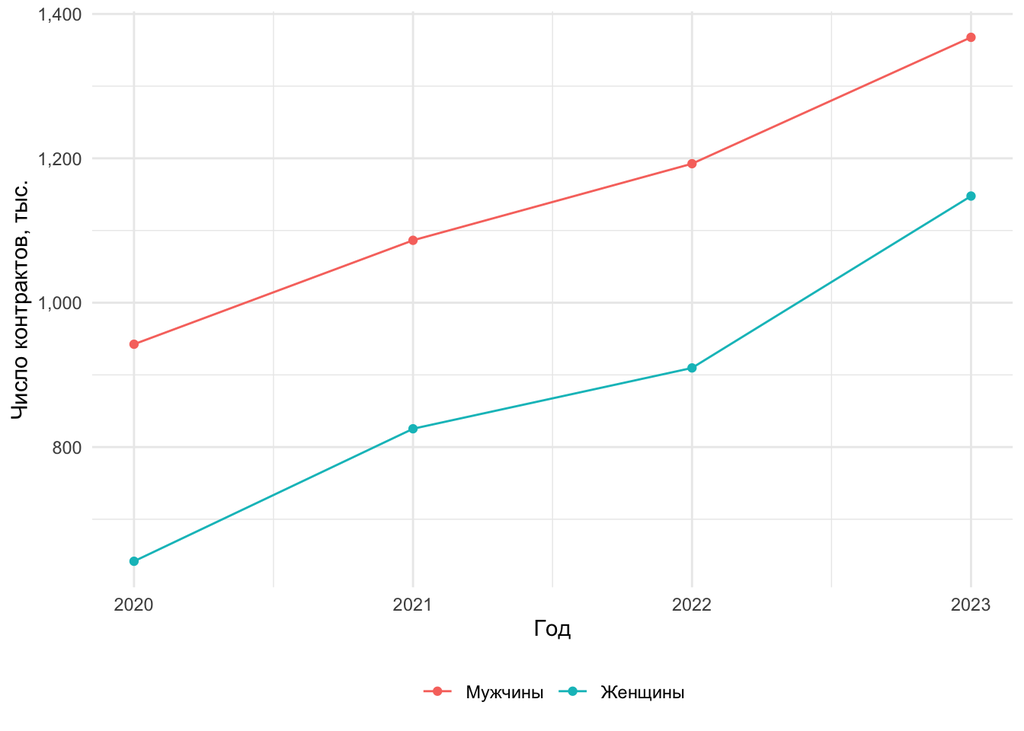

Число зарегистрированных контрактов растет для мужчин и женщин. Данные за 2024 год не включены.

Важно отметить, что доля женщин в числе контрактов увеличивается, хотя все еще остается довольно далекой от общей доли женщин в массе трудоспособного населения (около 52% согласно данным последним данным Бюро Национальной Статистики). Подобный диспаритет интересен тем, что он может отражать либо “объективную” реальность в которой женщины реже принимают решение работать в силу, например, нормативных представлений. Либо же могут отражать ситуацию в которой с женщинами реже заключают официальные трудовые договора. То есть женщины могут быть чаще чем мужчины заняты в сфера труда не попадающих в официальную статистику (например, челночная торговля).

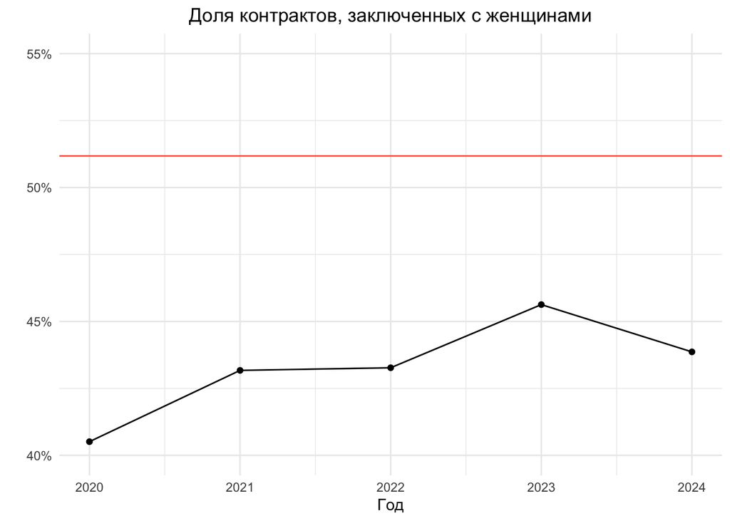

Доля контрактов заключенных с женщинами растет, однако остается далекой от общей доли женщин в трудоспособном возрасте (красная линия).

### 5.1.2. Половозрастная структура контрактов

Анализ половозрастной структуры трудовых договоров крайне важен для разработки государственных программ в сфере труда и социальной мобильности. С практической точки зрения, знание о половозрастной структуре помогает находить зоны дефицита кадров, проблемы занятости молодежи или прогнозировать последствия выхода на пенсию. Например, молодым работникам может потребоваться дополнительное обучение, а пожилым - переквалификация, чтобы адаптироваться к технологическому прогрессу. Гендерный анализ выявляет различия в приеме на работу, продвижении по службе и заработной плате, что позволяет принимать целенаправленные меры по обеспечению справедливости и соблюдению трудового законодательства. Эти данные крайне важны для разработки государственных политик таких как программы наставничества, гибкий график работы или инициатив по региональному развитию для удержания талантливых сотрудников.

Иными словами, анализ половозрастной структуры позволяет согласовывать стратегии привлечения персонала с требованиями рынка. Например, в некоторых отраслях, таких как технологии, может требоваться более молодая рабочая сила, в то время как здравоохранение часто выигрывает от более разнообразного возрастного распределения. Региональные и отраслевые тенденции, полученные на основе этих данных, помогают сформировать политику, направленную на устранение дисбаланса рабочей силы и обеспечение устойчивого экономического роста. Выявляя уникальные потребности и вклад различных демографических групп, подобный анализ способствует принятию эффективных управленческих решений.

В частности, для долгосрочного планирования важно понимать меняется ли половозрастная структура с течением времени. Например, рост доли пожилых работников может свидетельствовать о старении рабочей силы, что может потребовать политик по привлечению более молодых работников. И наоборот, увеличение числа молодых работников может свидетельствовать о необходимости расширения программ обучения или возможностей получения работы начального уровня.

Мы проанализируем изменение половозрастной структуры сначала на примере Бостандыкского района города Алматы, а затем повторим аналогичный анализ для всех административных регионов страны. На графиках ниже представлены половозрастные пирамиды контрактов с 2020 по 2023 заключенные в Бостандыкском районе Алматы. Заметно, что со временем растет доля работников молодого возраста - визуально основание пирамиды расширяется.

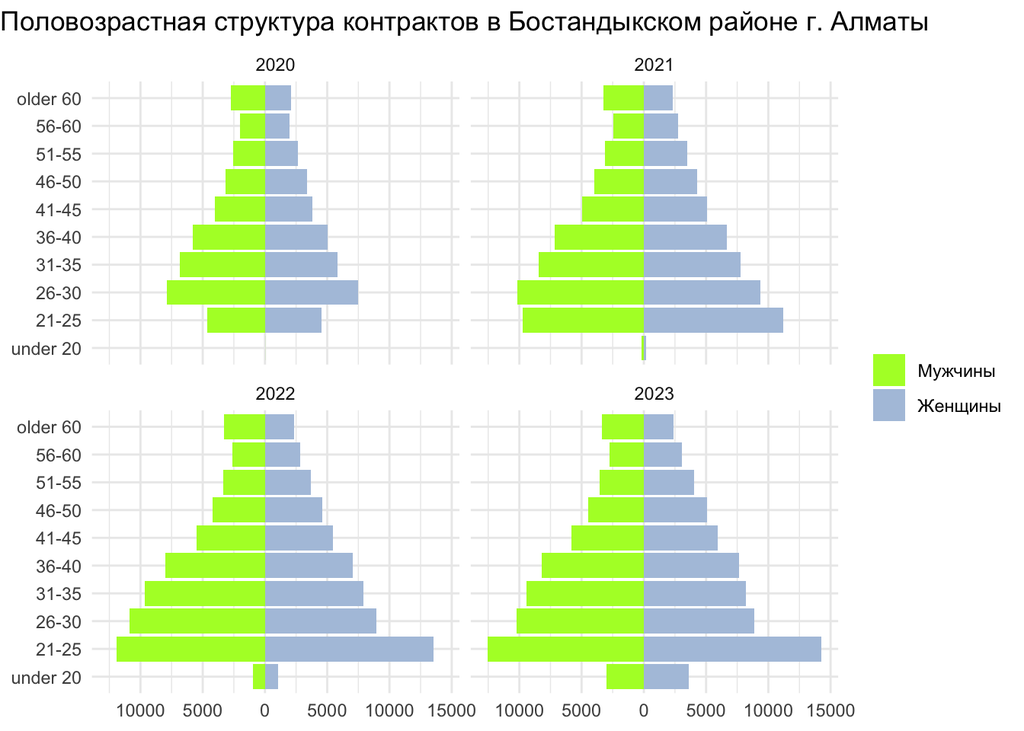

Доля контрактов, заключенных с молодыми работниками увеличивается со временем.

На следующей таблице представлены численные значения возрастов работников, с которыми заключались контракты. Обратите внимание, что если 2020 году было заключено всего 12(!) контрактов с индивидами моложе 20 лет, то в 2023 с ними было заключено уже 6626 контрактов (!!!).

Можно было бы проигнорировать этот стремительный рост как “артефакт” данных, однако он довольно логично согласуется с уже упомянутой “запаздывающей” регистрации договоров в системе ЕСУТД. Можно предположить, что изменения регуляторного режима заставило работодателей чаще регистрировать договора с молодыми работниками, что опять же является важным положительным последствием для системы защиты труда.

К тому же, дополнительный анализ показывает, что подавляющее большинство контраков с молодыми работниками были заключены крупными работодателями (например, сетью супермаркетов Магнум).

**Абсолютные значения**

| Возрастная группа | Год контракта 2020 | Год контракта 2021 | Год контракта 2022 | Год контракта 2023 |
| --- | --- | --- | --- | --- |
| under 20 | 12 | 376 | 2,023 | 6,626 |
| 21-25 | 9,149 | 20,943 | 25,498 | 26,853 |
| 26-30 | 15,369 | 19,499 | 19,799 | 19,083 |
| 31-35 | 12,636 | 16,178 | 17,572 | 17,638 |
| 36-40 | 10,853 | 13,816 | 15,060 | 15,804 |
| 41-45 | 7,866 | 10,026 | 10,977 | 11,731 |
| 46-50 | 6,495 | 8,204 | 8,831 | 9,589 |
| 51-55 | 5,233 | 6,622 | 7,041 | 7,538 |
| 56-60 | 3,991 | 5,186 | 5,405 | 5,836 |
| older 60 | 4,860 | 5,572 | 5,648 | 5,733 |

Таблица с количеством людей, заключивших контракт, по возрастным группам

**Проценты**

| Возрастная группа | Год контракта 2020 | Год контракта 2021 | Год контракта 2022 | Год контракта 2023 |
| --- | --- | --- | --- | --- |
| under 20 | 0.000 | 0.004 | 0.017 | 0.052 |
| 21-25 | 0.120 | 0.197 | 0.216 | 0.212 |
| 26-30 | 0.201 | 0.183 | 0.168 | 0.151 |
| 31-35 | 0.165 | 0.152 | 0.149 | 0.140 |
| 36-40 | 0.142 | 0.130 | 0.128 | 0.125 |
| 41-45 | 0.103 | 0.094 | 0.093 | 0.093 |
| 46-50 | 0.085 | 0.077 | 0.075 | 0.076 |
| 51-55 | 0.068 | 0.062 | 0.060 | 0.060 |
| 56-60 | 0.052 | 0.049 | 0.046 | 0.046 |
| older 60 | 0.064 | 0.052 | 0.048 | 0.045 |

Пропорции работников, заключивших контракт, по возрастным группам. Изменения в возрастной структуре статистически значимы(p-значение близко к нулю)

При всех этих оговорках, однако, возрастная структура рабочей силы в Бостандыкском районе претерпела значимое изменение - в целом доля молодых людей растет, и этот рост нельзя списать на статистические флуктуации.

Аналогичный тест мы проводим для прочих административных районов и обнаруживаем, что подобное изменение возрастной структура происходило и по всему Казахстану. Иными словами, везде в Казахстане пропорции разных возрастов изменились к 2023 году по сравнению с 2020. Таблица ниже показывает 5 самых высоких p-значения (т.е. показатели значимости) по районам, где видно, что единственным случаем с высоким p-значением, и следовательно низкой статистической значимостью, является Маркакольский район ВКО. Маркакольский район был образован в конце 2023 года и поэтому высокие p-значения для него попросту следует из отсутствия данных для сравнения.

| Район | Хи-квадрат тест |
| --- | --- |
| Восточно-Казахстанская область:район Марќакґл | 0.873 |
| Абай:район Жаѕасемей | 0.025 |
| Абай:район Маќаншы | 0.011 |
| Костанайская область:Наурзумский район | 0.002 |
| Акмолинская область:Коргалжынский район | 0.000 |

## 5.2. Структура профессиональной занятости по данным контрактов в системе ЕУСТД

### 5.2.1. Временная динамика профессиональной занятости

Понимание региональных распределений видов занятости также является важнейшим условием разработки адекватных программ регионального развития. Наши данные, как уже было сказано, содержали информацию о кодах професий (ОКЭД) по которым заключались трудовые контракты.

ОКЭДы в оригинальных данных были кодом из 5 позиций, где первые два числа опредляли общий класс занятости (например, Образование). То есть типичный ОКЭД для зарегистрированного трудового контракта выглядел бы как 85420, где первые два цифры кодируют общий класс - Образование, а добавляют деталей - в контексте примера, 85420 кодирует работу в сфере Высшего образования.

Для удобства, а также для повышения конфиденциальности, мы аггрегируем все ОКЭДы до общего уровня первых двух цифр. Таким образом, например, контракты по кодам 85420 и 85310, в анализируемых данных имеют одну общую категорию 85. Так, например, человек устроившийся продавцом в розничный супермаркет был бы учтен под ОКЭДом 47 - розничная торговля, а работник школы - под ОКЭДом 85, работа в сфере образования.

Как можно ожидать, ОКЭДы существенно варьируются в частоте. Так, например, на самый “популярный” ОКЭД 47, розничная торговля, приходится около 10% всех контрактов, в том время как на пятый по популярности ОКЭД 86, здравоохранение около 5%.

| Специальность | Число контрактов | Процент |
| --- | --- | --- |
| Розничная торговля | 1,016,976 | 10.85 |
| Образование | 981,264 | 10.47 |
| Оптовая торговля | 681,778 | 7.27 |
| Государственное управление и оборона | 460,738 | 4.92 |
| Деятельность в области здравоохранения | 456,510 | 4.87 |

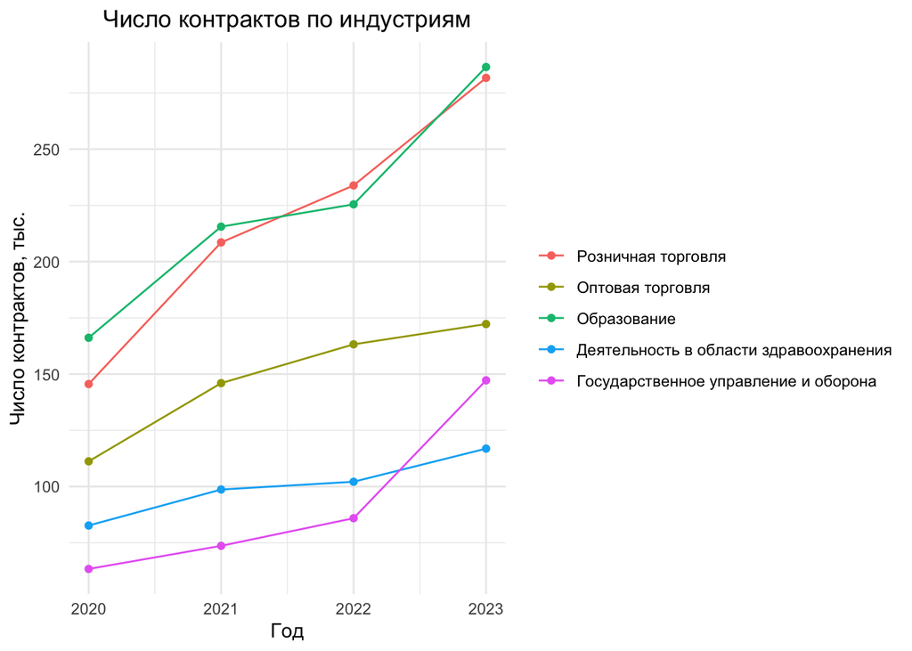

Больше всего трудовых контрактов заключается в сферах розничной торговли и образования. Данные за 2024 год не использовались.

### 5.2.2. Географическая структура профессиональной занятости

На графиках ниже представлена региональная специализация труда. Для каждой административной единицы мы расчитали самый “популярный” ОКЭД - то есть код, по котором, в данном регионе было заключено больше всего контрактов. Карта дает интересный инсайт в распределение професий по территории Казахстана. Так, например, мы видим, что в Костанайской и Северо-Казахстанской областях очень много районов, где основной ОКЭД - производство напитков (код 11). У нас нет какой-то законченной теории объясняющей популярность этой группы професий, но стоит отметить, что и Костанайская область и СКО - сельскохозяйственные регионы. Вероятно, довольно большое число професий в аграрном секторе проходят в классификации под кодом 11.

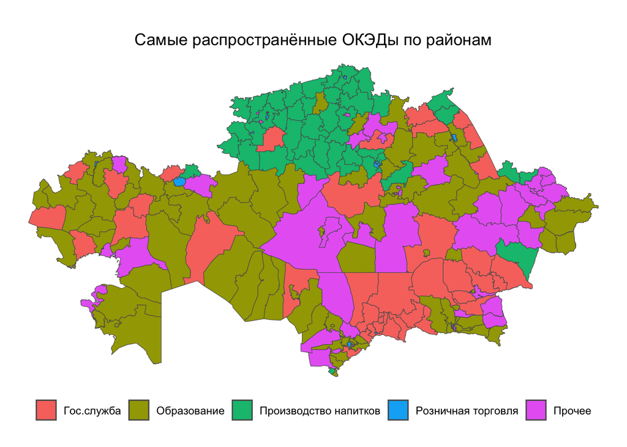

Карта ниже показывает распределение самого частого ОКЭДа, 47 - розничная торговля, по Казахстану. Тональность цвета отражает пропорцию этого кода в общем числе контрактов. Здесь примечательно то, что розничная торговля - это, в целом, прерогатива городов. Практически везде в сельской местности мы видим лишь малую долю индивидов занятых в рознице. Иными словами, самая популярная работа в Казахстане - это торговля, и практически вся торговля сконцентрирована в городах. Вероятно, что такая диспозиция, одна из причин миграции из сельской местности в города.

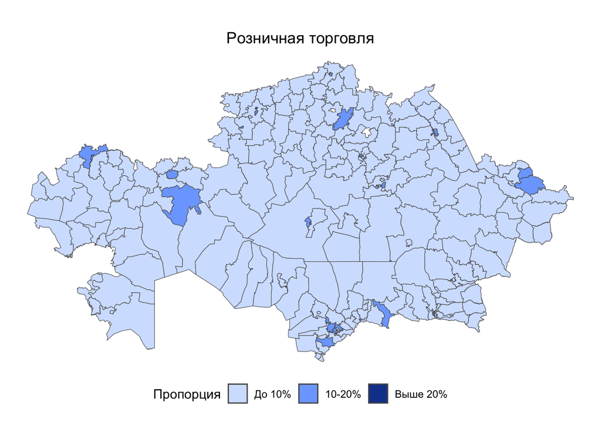

Пропорция 47 ОКЭДА по районам Казахстана

## 5.3. Сетевой анализ миграционных потоков

### 5.3.1. Социально-демографическая и профессиональная характеристика миграционных потоков

Наконец мы переходим к анализу непосредственно структуры трудовой мобильности между регионами. Понимание факторов, которые влияют на интенсивность смен работы между регионами, крайне важно для разработки эффективных программ регионального развития. Подобные программы часто пытаются удержать квалифицированных работников в определенной местности с помощью определенных экономических стимулов. Однако, далеко не все из этих стимулов равно эффективны. Соответственно, анализ потоков мобильности может дать более детальное представление о том, какие характеристики регионов увеличивают или уменьшают миграцию. При этом сетевая перспектива позволяет учесть сложные эндогенные взаимодействия между потоками.

Мы начинаем данный раздел с описательных характеристик потоков мобильности. В частности, с определения наиболее типичных професий по которым чаще всего происходит кросс-районная смена работы. Интересным является то, что частота контрактов по профессиям далеко не всегда связана с переездами. Например, сфера образования (код 85), которая является вторым по частоте заключаемых контрактов ОКЭДом в принципе, имеет меньше переездов, чем строительство (код 41), сфере в которой заключается существенно меньше контрактов. Это может говорить о том, что сфера образования относительно иммобильная, и работники занятые в ней реже меняют регионы проживания.

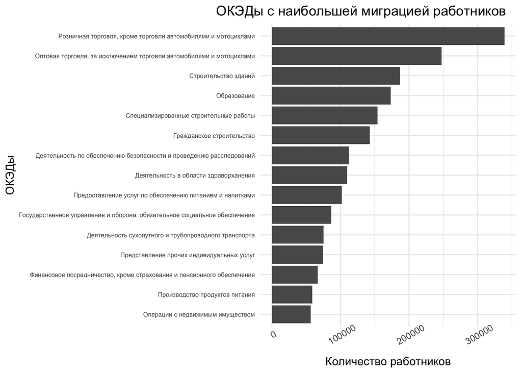

Данный график показывает самые распространенные ОКЭДы для мигрантов из других районов

Интерес также представляет гендерная структура ОКЭДов. Так на рисунке ниже мы видим, что многие классы професии имеют явно выраженную гендерную сегрегацию. Например, в образовании и розничной торговля относительно чаще работают женщины, а в строительстве (коды 42 и 43) и безопасности (код 80) гораздо чаще - мужчины.

Распределение полов по ОКЭДам.

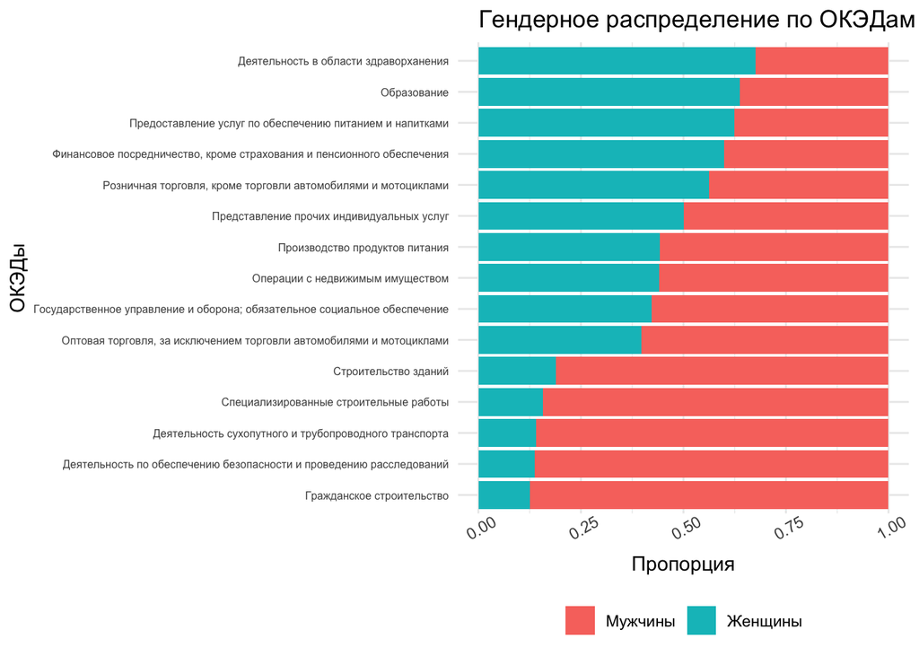

В разрезе возрастных групп классы професий обнаруживают заметные различия. Например, сфера безопасности является самой возрастной среди наиболее частых ОКЭДов, а розничная торговля, напротив, одной из самых молодых.

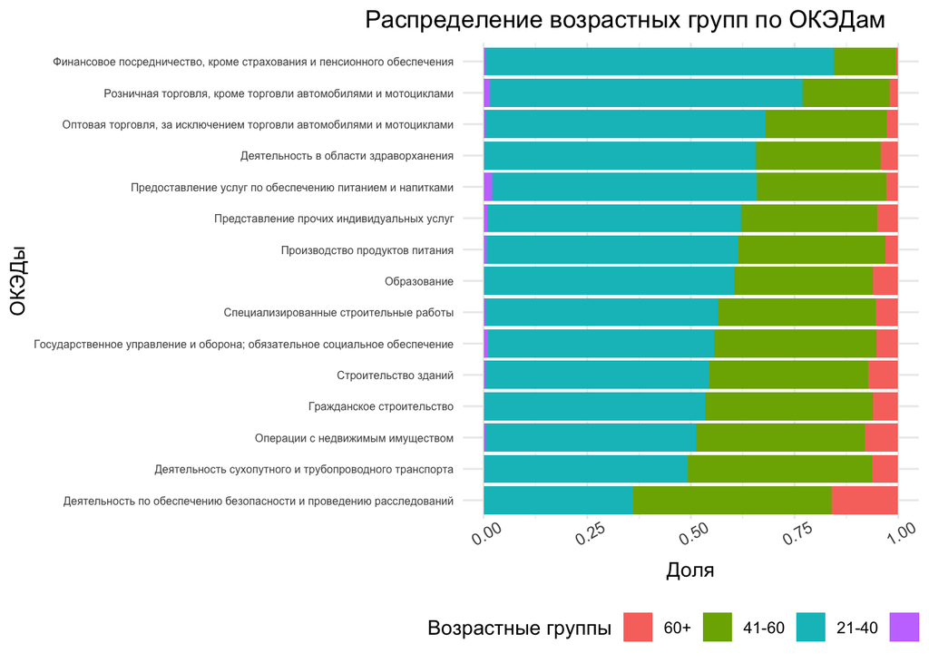

### 5.3.2. Сетевой анализ трудовой мобильности

В этом разделе мы анализурем непосредственно структуру сетей мобильности. Напомним, что наши данные позволяют нам видеть общее количество смен работы по определенным кодам професий между административными единицами второго уровня. Так мы можем видеть сколько человек сменило работу в сфере розничной торговли, например, между Ауэзовским и Бостандыкскими районами г. Алматы

Важным понятием сетевого анализа, который поможет нам пролить свет на структуру сети мобильности, является степень узла. Степенью узла для взвешенной сети называют общую сумму входящих или исходящих потоков. Степень узла, таким образом, позволяет нам оценить интенсивность приездов и убытий для определенных административных единиц.

На графике ниже представлена диаграмма рассеяния для входящих и исходящих степеней регионов. Мы видим, что между двумя характеристиками существует очень сильная корреляция. Если у узла высокая входящая степень (в него много приезжают), то у него также будет высокая исходящая степень (из него будут много уезжать). Иными словами, мигарция не является односторонним процессом, где индивиды строго перемещаются из одних мест в другие. Скорее наши данные показывают реципрокный характер трудовой миграции, где регионы убытия и прибытия связаны двусторонними потоками.

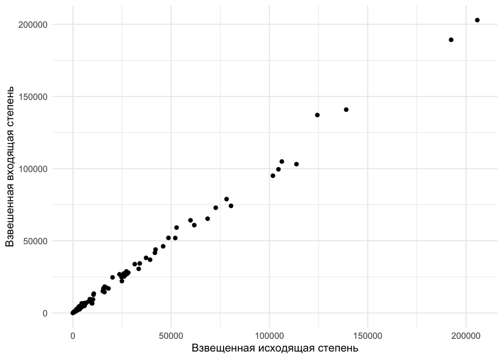

Важной характеристикой узлов в сетевом анализе является так называемая центральность по посредничеству. Посредничество показывает насколько часто определенный узел является “обязательным” промежуточным пунктом “проезда” при движении из одного региона в другой. Если использовать транспортную аналогию, то, например, у г. Астана будет высокое посредничество в транспортной сети, потому что на пути из южных регионов в северные большинство дорог будут проходить через Астану.

В контексте трудовой мобильности посредничество может указывать на то, как часто город становится “промежуточным” пунктом в трудовой карьере. Иными словами, если человек из Баянаульского района Павлодарской области сначала находит работу поселке Косшы (пригород Астаны), а затем уже и в самой Астане, то у Косшы будет относительно высокое посредничество.

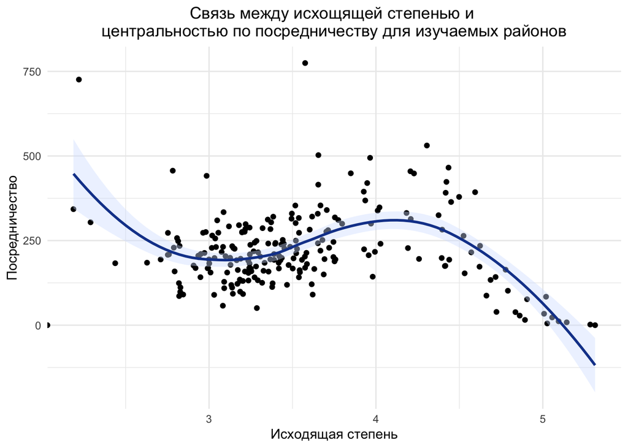

В целом у центральных районов крупных аггломераций как правило низкое посредничество. Например у Бостандыкского района г. Алматы оно вообще равно нулю и это при самой высокой степени. Такое может происходить в ситуации, когда центральные узлы окружены “защитным поясом” прочих районов. То что у Бостандыкского района нулевое посредничество формально значит, что нет ни одной пары прочих районов, которые бы были связаны через Бостандыкский, без того, чтобы быть связаными более коротким “путем”.

### 5.3.3. Миграционные кластера

Другой важной для анализа характеристикой сети является наличие кластеров - участков сети, узлы которых тесно связаны между собой и мало связаны с остальной сетью. В социальных сетях кластера обычно маркируют “группы друзей”. В миграционной же сети, кластер может маркировать группы регионов жители которых часто перемещаются внутри этих регионов и редко выезжают за его пределы.

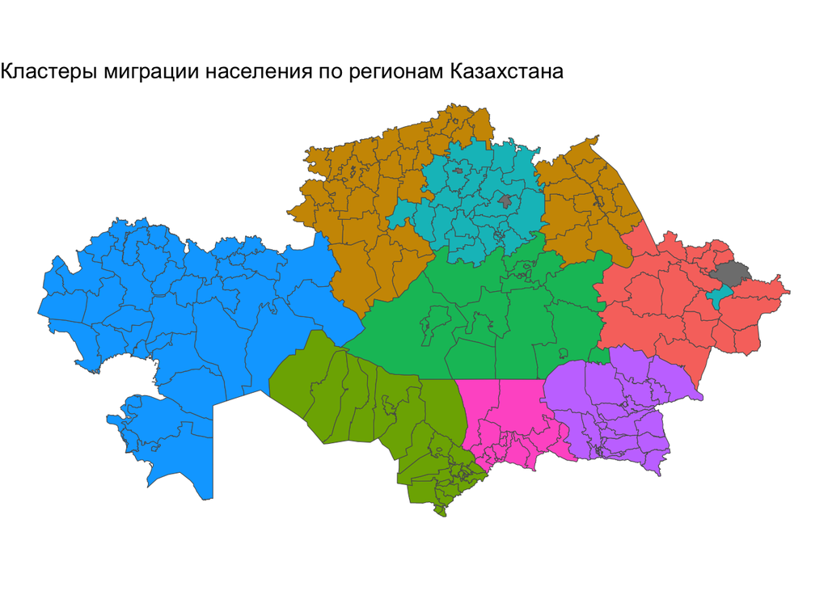

### 5.3.4. Моделирование основных потоков миграции

В конце аналитической части мы моделируем основные миграционные потоки между регионами используя так называемые Экспоненциальные Модели Случайных Графов (ERGM). Экспоненциальные графы - это метод моделирования структуры сети, в котором вероятность появления связи между узлами моделируется как функция самой сети и характеристик узлов. Это позволяет учесть эндогенный характер трудовой мобильности.

Условно, работу метода можно описать следующим образом. Процесс начинается с пустой сети, где у всех узлов нет никаких связей друг с другом. Затем случайным образом выбирается пара узлов и для них с определенной вероятностью возникает связь. Вероятность появления связи зависит от характеристик узлов, а также от состояния самой сети. Вероятность появляения связи например может увеличиваться если она связывает два узла с высокой популяцией, или может уменьшаться если она исходит из узла с высокой заработной платой (моделируя ситуацию, что индивиды реже переезжают из регионов с высокой заработной платой). Более того, связь учитывает текущее состояние сети, то есть ее вероятность может, например, увеличиваться, когда связь создает взаимную диаду (т.е. связь уже существовала в обратном направлении), или же когда она замыкает транзитивную триаду (связи были из региона А в регион Б, из региона Б в регион В, а новая связь соединила регион А с регионом В).

Этот пошаговый процесс повторяется очень долгое время пока сеть не приходит в стабильное состояние и ее характеристики (так называемые статистики) не перестают значимо изменяться. Как только сеть достигает равновесия, алгоритм завершает моделирование. Итогом становится модель, где вклад каждого механизма формирования сети оценивается с точки зрения вероятности.

В нашей работе, мы проверяем 3 модели формирования сети мобильности. Их общий вид можно описать следующим образом. Наша зависимая переменная это вероятность связи между районами

$$\begin{align*}
P(\textrm{Связь}_{ij} = 1) &\sim \text{Базовая вероятность}_{ij} \\
&+ \textrm{Взаимность}_{ij} \\
&+ \textrm{Характеристики р-н убытия}_{i} \\
&+ \textrm{Характеристики р-н прибытия}_{j} \\
&+ \textrm{Разница в хар-х р-нов прибытия и убытия}_{ij}
\end{align*}$$

В качестве характеристик районов мы учитывали

- Население районов (в тыс. чел.);
- Среднюю заработную плату в районе (в тыс. тенге);
- Рождаемость (в новорожденных на тыс. человек).

Результаты моделирования представлены на таблице ниже. Интерпретация аналогична логистической регресии: каждый коэффициент, если он значим, показывает как изменяются логарифмы шансов появления новой связи, если при ее появлении соответствующая характеристика сети изменяется на одну единицу. Иными словами, положительные коэффициенты говорят о том, что вероятность повышается, отрицательные - что уменьшается.

Из таблицы ниже видно, что как правило регионы реципрокными связями (идущими в оба направления). Численность населения отбытия и прибытия также играет роль: индивиды чаще уезжают и приезжают в районы с высоким населением. Однако интересно то, что абсолютная разница в численности не играет большой роли. Это говорит о том, что нет выраженной тенденции переезжать из сильнонаселенных регионов в слабонаселенные.

Наконец, интересным коррелятом межрегиональных связей является разница в средней рождаемости - чем она выше, тем меньше вероятность связи. Этот эффект может косвенно свидетельствовать о географических и культурных факторах мобильности - индивиды чаще меняют работу внутри регионов похожих по средней рождаемости.

|  | модель 1 | модель 2 | модель 3 |
| --- | --- | --- | --- |
| (Edges intercept) | −6.885*** | −7.868*** | −7.256*** |
|  | (0.102) | (0.153) | (0.191) |
| Взаимность (Mutual) | 7.544*** | 7.518*** | 7.483*** |
|  | (0.200) | (0.201) | (0.205) |
| Входящая связь: Население района | 0.003*** | 0.003*** | 0.003*** |
|  | (0.001) | (0.001) | (0.001) |
| Исходящая связь: Население района | 0.005*** | 0.004*** | 0.005*** |
|  | (0.001) | (0.001) | (0.001) |
| Разница: Население района | 0.000 | 0.000 | 0.000 |
|  | (0.000) | (0.000) | (0.000) |
| Входящая связь: Средняя з/п в районе |  | 0.005*** | 0.005*** |
|  |  | (0.001) | (0.001) |
| Исходящая связь: Средняя з/п в районе |  | 0.002 | 0.002 |
|  |  | (0.001) | (0.001) |
| Разница: Средняя з/п в районе |  | −0.003*** | −0.003*** |
|  |  | (0.001) | (0.001) |
| Разница: Число новорождённых на 1 тыс. чел. |  |  | −0.034*** |
|  |  |  | (0.005) |
| Num.Obs. | 47306 | 47306 | 47306 |
| AIC | 4814.0 | 4744.2 | 4683.0 |
| BIC | 4857.9 | 4814.3 | 4779.4 |

Модели экспоненциальных случайных графов.

# 6. Приложение 1. Коды популярных ОКЭДов

| Код | Расшифровка |
| --- | --- |
| 47 | Розничная торговля, кроме торговли автомобилями и мотоциклами |
| 46 | Оптовая торговля, за исключением торговли автомобилями и мотоциклами |
| 41 | Строительство зданий |
| 85 | Образование |
| 43 | Специализированные строительные работы |
| 42 | Гражданское строительство |
| 80 | Деятельность по обеспечению безопасности и проведению расследований |
| 86 | Деятельность в области здравоохранения |
| 56 | Предоставление услуг по обеспечению питанием и напитками |
| 84 | Государственное управление и оборона; обязательное социальное обеспечение |
| 49 | Деятельность сухопутного и трубопроводного транспорта |
| 96 | Предоставление прочих индивидуальных услуг |
| 64 | Финансовое посредничество, кроме страхования и пенсионного обеспечения |
| 10 | Производство продуктов питания |
| 68 | Операции с недвижимым имуществом |